# Cleaned Results

Erin M. Buchanan

Last Knitted: 2022-09-28

## 3.1 Sample characteristics

Sample characteristics for all 600 articles are displayed in Table 2 and Figure 1. 81 (13.5%) Articles were excluded due to not being in English (0.2%), not being about language according to our definition above (9.7%), not being accessible (2.2%) or other reasons (1.5%).

(#tab:table1)

*Sample Study Characteristics*

| Metric | Total | Pre.OS | After.OS |
| --- | --- | --- | --- |
| Coded Articles | 600 | 300 | 300 |
| Included Articles | 519 | 264 | 255 |
| Number Journals | 274 | 168 | 185 |
| Number Languages | 84 | 58 | 53 |
| JIF | 1.22 (0.86) Mdn = 0.99 | 1.01 (0.81) Mdn = 0.8 | 1.44 (0.86) Mdn = 1.39 |
| Number of Countries | 61 | 45 | 47 |
| Study Design - Empirical | 363 | 175 | 188 |
| Study Design - Not Empirical | 152 | 87 | 65 |
| Study Design - Meta-Analysis | 4 | 2 | 2 |
| Study Data - Primary | 263 | 123 | 140 |
| Study Data - Secondary | 97 | 50 | 47 |
| Study Data - Other | 3 | 2 | 1 |

*Note.* All values are raw counts on the original sample size, except JIF which represents the mean and standard deviation. Empirical study data type was categorized after examination of the results.

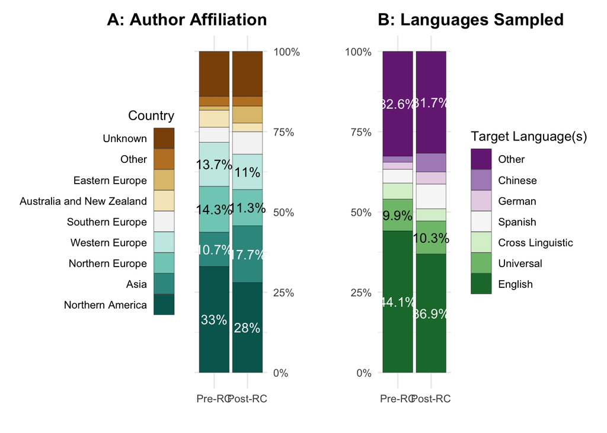

Figure 1. A: The proportion of first author affiliation’s country binned into United Nations Subregions collapsing all Asian subregions together and all other non-visualized regions as the other category. B: The proportion of languages examined in these studies collapsing all other languages together. Cross Linguistic samples represented studies with five or more languages.

While the difference between articles published in our early and our late time window have similar sample properties, there are general noteworthy asymmetries in our sample. First and foremost, we notice a very strong anglocentric bias for both the host country of the corresponding author and the language under investigation, as shown in Figure 1. A large portion of studies are conducted with first author affiliations in the United States, United Kingdom, or Europe, and the primary language under investigation is English. While these properties may be tied to the sampling of English-written articles, these asymmetries quantify often articulated concerns that claims about human language are too often based on a small set of languages, limiting their generalisability (e.g. Majid & Levinson 2010, Goddard & Wierzbicka 2014, Levisen 2018).

Linguistics is a multidisciplinary field with many different empirical traditions. Our sample contained a wide variety of study types which we tried to categorize into three categories (empirical data, no empirical data, meta-analysis). From these categories, we attempted to label empirical data into seven proposed categories. Coding of these categories was often difficult due to a lack of clear-cut definitions between them. In order to describe the patterns observed in a digestible way, we will subsume study types into three super categories that are defined by the relationship between the data and the analysis: 1) Primary data defined as data collected during the study (including experimental studies, observational studies, correlational studies, field studies or language description, case studies, surveys, and interviews), 2) Secondary data defined as data from previous data collections or reanalysis (including corpus studies, descriptions of archives, discourse analyses, secondary data analyses from published data, typological studies), and 3) Other category which does not fit the former two definitions and for which most coded measures are irrelevant (modeling, simulations, introspections, formal linguistic analyses). After coding these values, we found very few Other category articles, but several articles that included multiple types of data. In order to ensure that count values were represented only once in the following descriptions, each was coded as Primary if it contained any Primary data, Secondary if it was coded as Secondary and Other, and Other was reserved for studies with only Other data. These counts can be found in Table 2. The Other category was excluded for analyses below that focused on primary and secondary data.

## 3.2 Article availability (open access)

Among the 360 eligible empirical study data articles (primary and secondary), we obtained a publicly available version for 129 (35.8%), whereas 208 (57.8%) were only accessible through a paywall. 23 (6.4%) articles were not available at all.

This rate was approximately the same when we examine the entire (*n* = 600) or coded (*n* = 519) datasets. For the entire dataset, 211 (35.2%) were available, 342 (57%) were paywalled, and 47 (7.8%) were not available. For the coded dataset, 192 (37%) were available, 292 (56.3%) were paywalled, and 35 (6.7%) were not available.

## 3.3 Materials availability

For the 57 articles for which materials were reportedly available, the materials were not actually available for 4 articles because of broken links. For the 53 articles that we could access, the materials were made available in the article itself (e.g., in a table or appendix; *n* = 10), in a journal-hosted supplement (*n* = 16), on a personal or institutionally hosted (nonrepository) webpage (*n* = 3), or in an online third-party repository (*n* = 20). All other materials locations were coded as other.

## 3.4 Data availability

### Raw data

Of those articles published in 2008/2009 and involving primary data, 8 (6.5%) contained a statement or link regarding the availability of raw data such as audio recordings, transcriptions or data provided by experimental software. Of those articles involving secondary data, 17 (34%) articles contained such a statement or link. Of those articles published in 2018/2019 and involving primary data, 5 (3.6%) contained such a statement or link. Of those articles involving secondary data, 20 (42.6%) articles contained such a statement or link.

For the 50 articles for which raw data were reportedly available, the data were not actually available for 6 articles because of broken links or availability “upon request”. For the articles that we could access, the raw data were made available in a journal-hosted supplement (*n* = 4), on a personal or institutionally hosted (nonrepository) webpage (*n* = 2), or in an online third-party repository (*n* = 38). Of those articles, 6 data sources were documented.

### Derived data

For the 12 articles for which derived data were reportedly available, the data were not actually available for 3 articles because of broken links or availability “upon request”. For the articles that we could access, the derived data were made available in a journal-hosted supplement (*n* = 4), on a personal or institutionally hosted (nonrepository) webpage (*n* = 1), or in an online third-party repository (*n* = 4). Of those articles, 3 data sources were documented.

## 3.5 Analysis-script availability

Of the 360 articles that involved primary or secondary data, an analysis script was shared for 3 articles (0.8%). The scripts were made available in a journal-hosted supplement (*n* = 3), or in an online third-party repository (*n* = 0).

## 3.6 Preregistration

No articles across all coded articles (*n* = 519) was preregistered.

## 3.7 Replication

Of the 360 articles that were experimental, 4 articles (1.1%) were replications according to the definition used in Kobrock & Roettger (2022): “We first searched for the search string”replic*” and if we got a hit, we examined title and abstract of the paper, text before and after occurrences of the search term replicat*, the paragraph before the Methods section as well as the first paragraph of the Discussion section. If the authors explicitly claimed that (one of) their research aim(s) was to replicate the result or methods of an initial study, this article was treated as a replication.” Following Marsden et al. (2018), replication studies were classified according to the number of changes made into three categories: direct replication (0 changes), partial replication (1 change) and conceptual replication (2 or more changes). Of those that were classified as replications, all four were conceptual replications.

## 3.8 Conflict-of-interest statements

Of the 519 coded articles, 52 included a statement about conflicts-of-interest (10%). All of these articles stated that there was no conflict of interest.

## Discussion

```r
# overall statistics calculated by year, study data type, type of transparency measure
fig2_data2 %>%
  select(year_split, EmpiricalStudyData, Type, n, prop, available) %>%
  print(., n = nrow(fig2_data2))
```

```
## # A tibble: 30 × 6
## # Groups:   year_split, EmpiricalStudyData [4]
##    year_split          EmpiricalStudyData Type                  n  prop availa…¹
##    <fct>               <fct>              <fct>             <int> <dbl> <fct>
##  1 Post-RC (2018-2019) Primary            "Materials "        106  75.7 " Not a…
##  2 Post-RC (2018-2019) Primary            "Materials "         34  24.3 " Avail…
##  3 Post-RC (2018-2019) Secondary          "Materials "         43  91.5 " Not a…
##  4 Post-RC (2018-2019) Secondary          "Materials "          4   8.5 " Avail…
##  5 Pre-RC (2008-09)    Primary            "Materials "        104  85.2 " Not a…
##  6 Pre-RC (2008-09)    Primary            "Materials "         18  14.8 " Avail…
##  7 Pre-RC (2008-09)    Secondary          "Materials "         47  97.9 " Not a…
##  8 Pre-RC (2008-09)    Secondary          "Materials "          1   2.1 " Avail…
##  9 Post-RC (2018-2019) Primary            "Raw Data "           5   3.6 " Avail…
## 10 Post-RC (2018-2019) Secondary          "Raw Data "          20  42.6 " Avail…
## 11 Pre-RC (2008-09)    Primary            "Raw Data "           8   6.5 " Avail…
```

[output cut: 20 more lines]

```r
# statistics calculated by year, type of transparency measure (summed over study data type)
fig2_data2 %>%
  group_by(year_split, Type, available) %>%
  summarise(total_n = sum(n), .groups = "keep") %>%
  group_by(year_split, Type) %>%
  mutate(total_prop = total_n / sum(total_n) * 100)
```

```
## # A tibble: 15 × 5
## # Groups:   year_split, Type [8]
##    year_split          Type              available        total_n total_prop
##    <fct>               <fct>             <fct>              <int>      <dbl>
##  1 Pre-RC (2008-09)    "Materials "      " Available"          19      11.2
##  2 Pre-RC (2008-09)    "Materials "      " Not available"     151      88.8
##  3 Pre-RC (2008-09)    "Raw Data "       " Available"          25      14.5
##  4 Pre-RC (2008-09)    "Raw Data "       " Not available"     148      85.5
##  5 Pre-RC (2008-09)    "Processed Data " " Available"           3       1.73
##  6 Pre-RC (2008-09)    "Processed Data " " Not available"     170      98.3
##  7 Pre-RC (2008-09)    "Analysis "       " Not available"     173     100
##  8 Post-RC (2018-2019) "Materials "      " Available"          38      20.3
##  9 Post-RC (2018-2019) "Materials "      " Not available"     149      79.7
## 10 Post-RC (2018-2019) "Raw Data "       " Available"          25      13.4
## 11 Post-RC (2018-2019) "Raw Data "       " Not available"     162      86.6
## 12 Post-RC (2018-2019) "Processed Data " " Available"           9       4.81
## 13 Post-RC (2018-2019) "Processed Data " " Not available"     178      95.2
## 14 Post-RC (2018-2019) "Analysis "       " Available"           3       1.60
## 15 Post-RC (2018-2019) "Analysis "       " Not available"     184      98.4
```

```r
# statistics calculated by study data type, transparency measured (summed over years)
fig2_data2 %>%
  group_by(EmpiricalStudyData, Type, available) %>%
  summarise(total_n = sum(n), .groups = "keep") %>%
  group_by(EmpiricalStudyData, Type) %>%
  mutate(total_prop = total_n / sum(total_n) * 100)
```

```
## # A tibble: 16 × 5
## # Groups:   EmpiricalStudyData, Type [8]
##    EmpiricalStudyData Type              available        total_n total_prop
##    <fct>              <fct>             <fct>              <int>      <dbl>
##  1 Secondary          "Materials "      " Available"           5      5.26
##  2 Secondary          "Materials "      " Not available"      90     94.7
##  3 Secondary          "Raw Data "       " Available"          37     38.1
##  4 Secondary          "Raw Data "       " Not available"      60     61.9
##  5 Secondary          "Processed Data " " Available"           6      6.19
##  6 Secondary          "Processed Data " " Not available"      91     93.8
##  7 Secondary          "Analysis "       " Available"           2      2.06
##  8 Secondary          "Analysis "       " Not available"      95     97.9
##  9 Primary            "Materials "      " Available"          52     19.8
## 10 Primary            "Materials "      " Not available"     210     80.2
## 11 Primary            "Raw Data "       " Available"          13      4.94
## 12 Primary            "Raw Data "       " Not available"     250     95.1
## 13 Primary            "Processed Data " " Available"           6      2.28
## 14 Primary            "Processed Data " " Not available"     257     97.7
## 15 Primary            "Analysis "       " Available"           1      0.380
## 16 Primary            "Analysis "       " Not available"     262     99.6
```

```r
# statistics calculated by study data type (summed over transparency measures and years )
fig2_data2 %>%
  group_by(Type, available) %>%
  summarise(total_n = sum(n), .groups = "keep") %>%
  group_by(Type) %>%
  mutate(total_prop = total_n / sum(total_n) * 100)
```

```
## # A tibble: 8 × 4
## # Groups:   Type [4]
##   Type              available        total_n total_prop
##   <fct>             <fct>              <int>      <dbl>
## 1 "Materials "      " Available"          57     16.0
## 2 "Materials "      " Not available"     300     84.0
## 3 "Raw Data "       " Available"          50     13.9
## 4 "Raw Data "       " Not available"     310     86.1
## 5 "Processed Data " " Available"          12      3.33
## 6 "Processed Data " " Not available"     348     96.7
## 7 "Analysis "       " Available"           3      0.833
## 8 "Analysis "       " Not available"     357     99.2
```

```r
# open access statistics after fixing coding issues on the initial dataset (n = 600) by year
openaccessDF_all %>%
  group_by(open_access, year_split) %>%
  summarize(total_n = n(), .groups = "keep") %>%
  group_by(year_split) %>%
  mutate(open_prop = total_n / sum(total_n) * 100)
```

```
## # A tibble: 6 × 4
## # Groups:   year_split [2]
##   open_access year_split total_n open_prop
##   <chr>       <chr>        <int>     <dbl>
## 1 no          After-OS       144     48
## 2 no          Pre-OS         198     66
## 3 unknown     After-OS        29      9.67
## 4 unknown     Pre-OS          18      6
## 5 yes         After-OS       127     42.3
## 6 yes         Pre-OS          84     28
```

```r
# open access statistics on the included dataset (n = 519) by year
openaccessDF_used %>%
  group_by(open_access, year_split) %>%
  summarize(total_n = n(), .groups = "keep") %>%
  group_by(year_split) %>%
  mutate(open_prop = total_n / sum(total_n) * 100)
```

```
## # A tibble: 6 × 4
## # Groups:   year_split [2]
##   open_access year_split total_n open_prop
##   <chr>       <chr>        <int>     <dbl>
## 1 no          After-OS       119     46.7
## 2 no          Pre-OS         173     65.5
## 3 unknown     After-OS        21      8.24
## 4 unknown     Pre-OS          14      5.30
## 5 yes         After-OS       115     45.1
## 6 yes         Pre-OS          77     29.2
```

```r
# open access statistics on the included articles reporting empirical studies (n = 360) by year
openaccessDF_filtered %>%
  group_by(open_access, year_split) %>%
  summarize(total_n = n(), .groups = "keep") %>%
  group_by(year_split) %>%
  mutate(open_prop = total_n / sum(total_n) * 100)
```

```
## # A tibble: 6 × 4
## # Groups:   year_split [2]
##   open_access year_split total_n open_prop
##   <chr>       <chr>        <int>     <dbl>
## 1 no          After-OS        93     49.7
## 2 no          Pre-OS         115     66.5
## 3 unknown     After-OS        13      6.95
## 4 unknown     Pre-OS          10      5.78
## 5 yes         After-OS        81     43.3
## 6 yes         Pre-OS          48     27.7
```

```r
# replication statistics on the included articles reporting empirical studies (n = 360) by year
# note that we double checked these and one was not a replication study and was miscoded
DF_filtered_ps$Replication[DF_filtered_ps$Replication == ""] <- "There is no clear statement that the article reports a replication study (or studies)"
DF_filtered_ps %>%
  group_by(Replication, year_split) %>%
  summarize(total_n = n(), .groups = "keep")
```

```
## # A tibble: 4 × 3
## # Groups:   Replication, year_split [4]
##   Replication                                                    year_…¹ total_n
##   <chr>                                                          <chr>     <int>
## 1 The article claims to report a replication study (or studies)  After-…       1
## 2 The article claims to report a replication study (or studies)  Pre-OS        4
## 3 There is no clear statement that the article reports a replic… After-…     186
## 4 There is no clear statement that the article reports a replic… Pre-OS      169
## # … with abbreviated variable name ¹year_split
```

```r
# coi statistics on the included dataset (n = 519) by year
DF_filtered$COI[DF_filtered$COI == ""] <- "No, there is no conflict of interest statement"
DF_filtered %>%
  group_by(COI, year_split) %>%
  summarize(total_n = n(), .groups = "keep") %>%
  group_by(COI) %>%
  mutate(COI_prop = total_n / sum(total_n) * 100)
```

```
## # A tibble: 4 × 4
## # Groups:   COI [2]
##   COI                                                    year_…¹ total_n COI_p…²
##   <chr>                                                  <chr>     <int>   <dbl>
## 1 No, there is no conflict of interest statement         After-…     209    44.8
## 2 No, there is no conflict of interest statement         Pre-OS      258    55.2
## 3 Yes, the statement says that there is no conflict of … After-…      46    88.5
## 4 Yes, the statement says that there is no conflict of … Pre-OS        6    11.5
## # … with abbreviated variable names ¹year_split, ²COI_prop
```